# BF_Midterm

Ritik Kumar

2024-11-04

## Importing the Data

```r
library(fpp)
library(fpp2)
```

```r
library(ggplot2)
library(forecast)
library(readr)
library(dplyr)
sales_data <- read_csv("sales.csv")
head(sales_data)
```

```
## # A tibble: 6 × 2
##   Dates    Sales
##   <chr>    <dbl>
## 1 1/1/2020 1502.
## 2 2/1/2020 1322.
## 3 3/1/2020 1422.
## 4 4/1/2020 1442.
## 5 5/1/2020 1797.
## 6 6/1/2020 1645.
```

## Introduction about Dataset

- The dataset represents the sales of a healthcare product manufactured by a pharmaceutical company in the U.S. Because the production process for this drug is lengthy and time-consuming, it’s crucial to forecast sales accurately. By predicting future sales, we can optimize the manufacturing schedule, ensuring that production aligns closely with demand. This forecasting approach helps the company maintain a steady supply of the drug, allowing customer orders to be fulfilled immediately.
- First we are successfully importing the data.
- Then we are displaying the first few rows for confirmation that are dataset is imported successfully

## Plot and Inference

##### Converting data into Times Series and then Plotting it

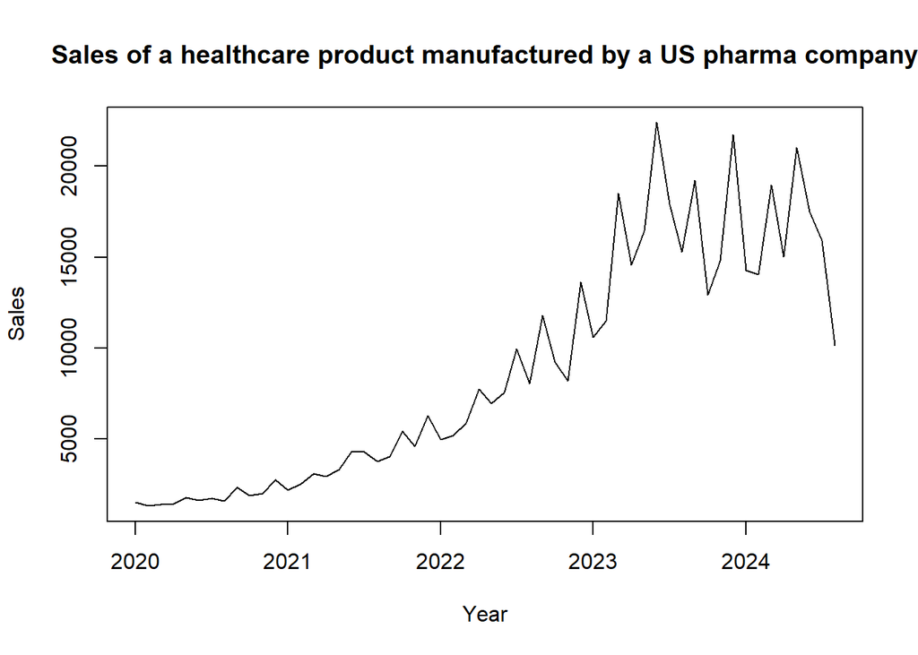

```r
sales_ts <- ts(sales_data$Sales, frequency = 12, start = c(2020,1), end=c(2024,8))
plot(sales_ts, main="Sales of a healthcare product manufactured by a US pharma company", xlab="Year", ylab="Sales")
```

- we start with plotting the time series for visualization and understand the data correctly

## Central Tendency

##### Min, max, mean, median, 1st and 3rd Quartile values of the times series

```r
summary(sales_ts)
```

```
##    Min. 1st Qu.  Median    Mean 3rd Qu.    Max.
##    1322    2892    7246    8753   14346   22397
```

- The summary function above gives the min, max, mean, median, 1st and 3rd Quartile values of the times series.

##### Show the Box Plot

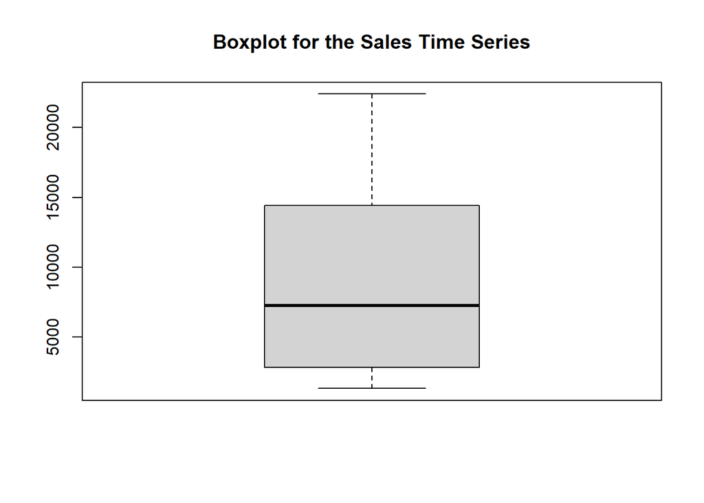

```r
boxplot(sales_ts, main ='Boxplot for the Sales Time Series')
```

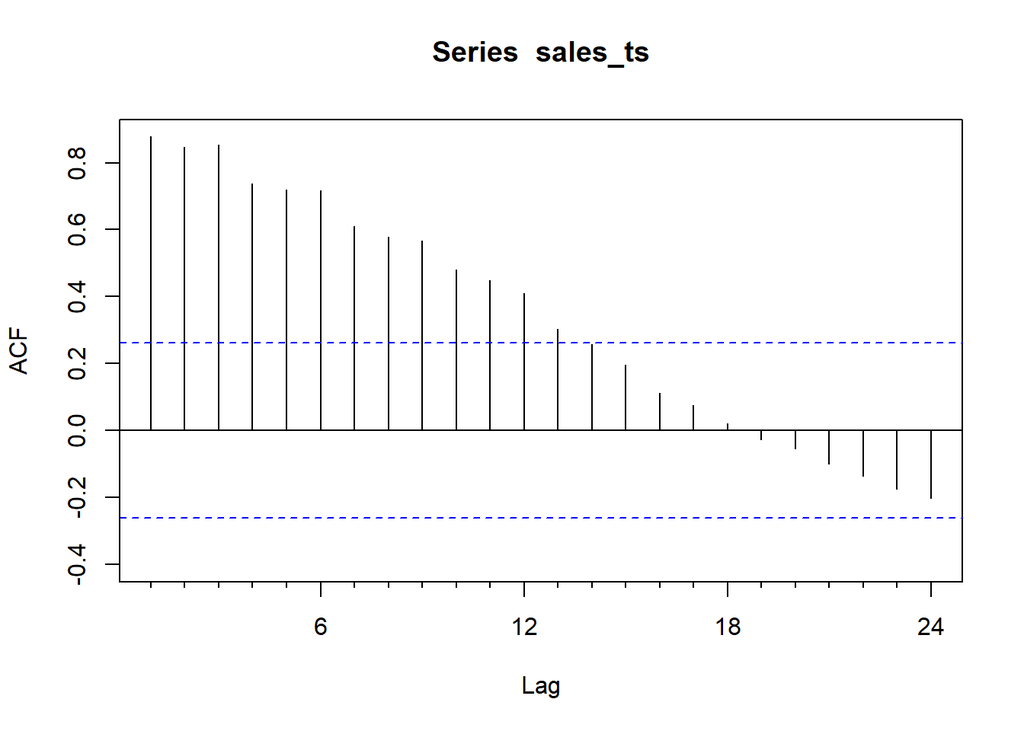

```r
Acf(sales_ts)
```

##### Observations and Inferences

- The boxplot shows that there are no outliers in the data.
- The median is more towards the first quartile.
- From summary, we can also see that the median value is less then the mean value for the time series.
- This means that the data is right skewed. This can be justified seeing the boxplot as well.
- From the ACF plot, we can see that many of the values crossed the confidence intervals, stating there is a trend component in the data.
- Also, we can see that after 18th lag period, the ACF plot is dipping into the negative values stating seasonality also exists in the data.

## Decomposition

##### Decomposition Plot

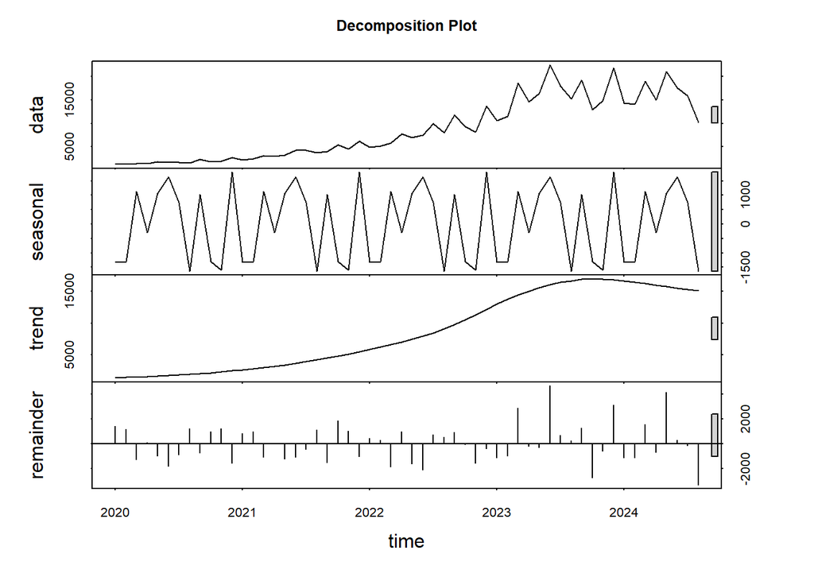

```r
stl_decomp <- stl(sales_ts, s.window = "periodic")
plot(stl_decomp, main = 'Decomposition Plot')
```

##### Is the time series seasonal?

- Yes, the time series is seasonal.

##### Is the decomposition additive or multiplicative?

```r
decom <- decompose(sales_ts)
decom$type
```

```
## [1] "additive"
```

- The decomposition seems to be additive.
- Because, with as trend increases, we do not see any increase in the seasonality. The seasonality appears to be the same throughout.

##### If seasonal, what are the values of the seasonal monthly indices?

```r
decom$figure
```

```
##  [1] -1637.61383 -1562.74459  1068.72820   -57.46680    87.83035  2154.71713
##  [7]   753.35870  -814.83057  1059.15192 -1259.70934 -1565.32609  1773.90491
```

##### Seasonality adjusted plot

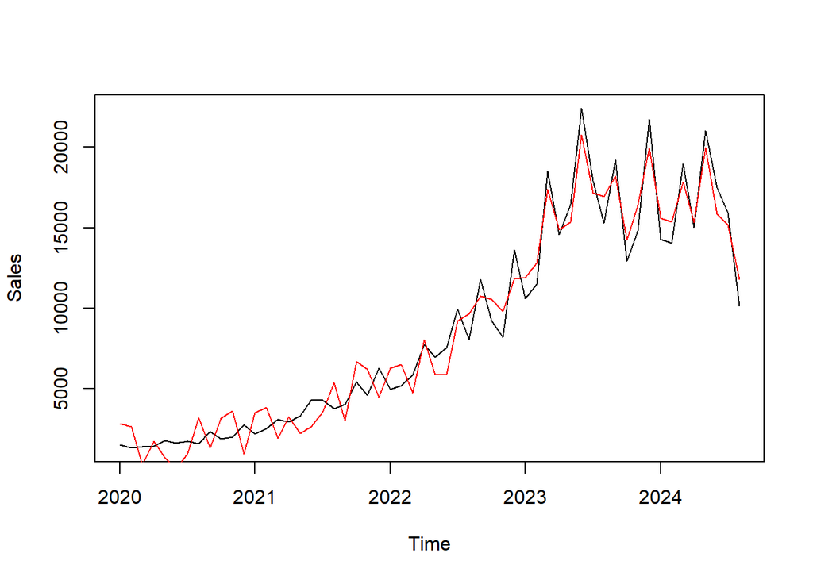

```r
plot(sales_ts, ylab = 'Sales')
lines(seasadj(stl_decomp), col="Red")
```

- There are high fluctuations that can be observed after applying seasonal adjustment.
- With time, these fluctuations will cause more deviations and change our forecast. So, it is important to consider the seasonal variation in the data.

## Testing the various Forecasting methods for the given dataset

## Naive Method

##### Output

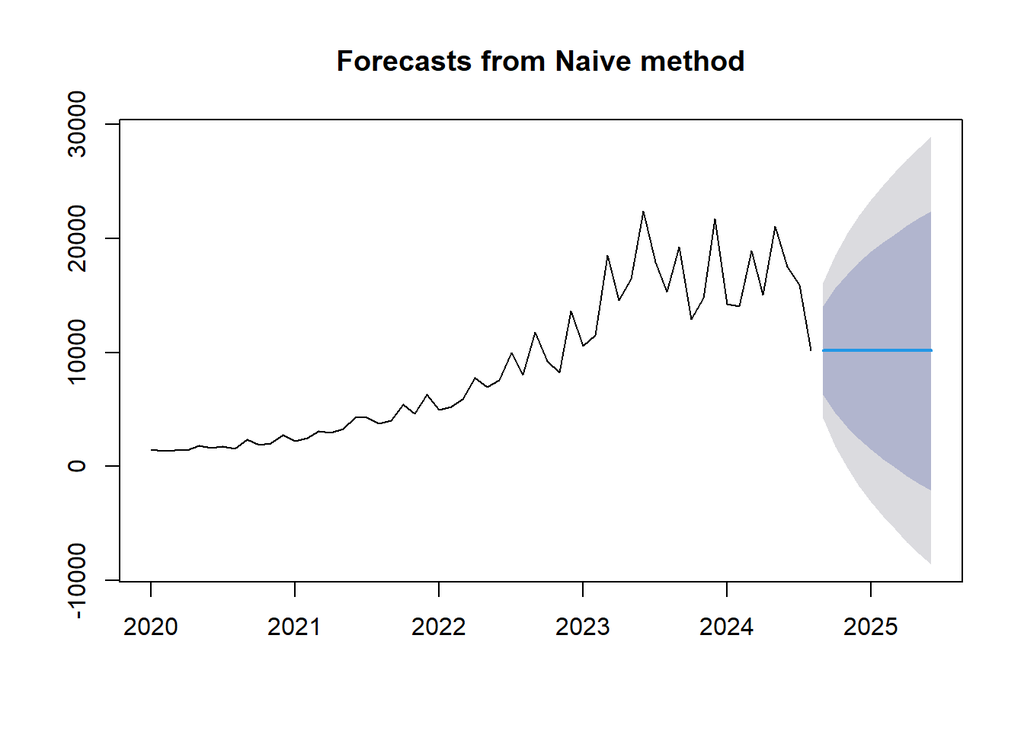

```r
naive_forecast <- naive(sales_ts)
plot(naive_forecast)
```

##### Perform Residual Analysis for this technique.

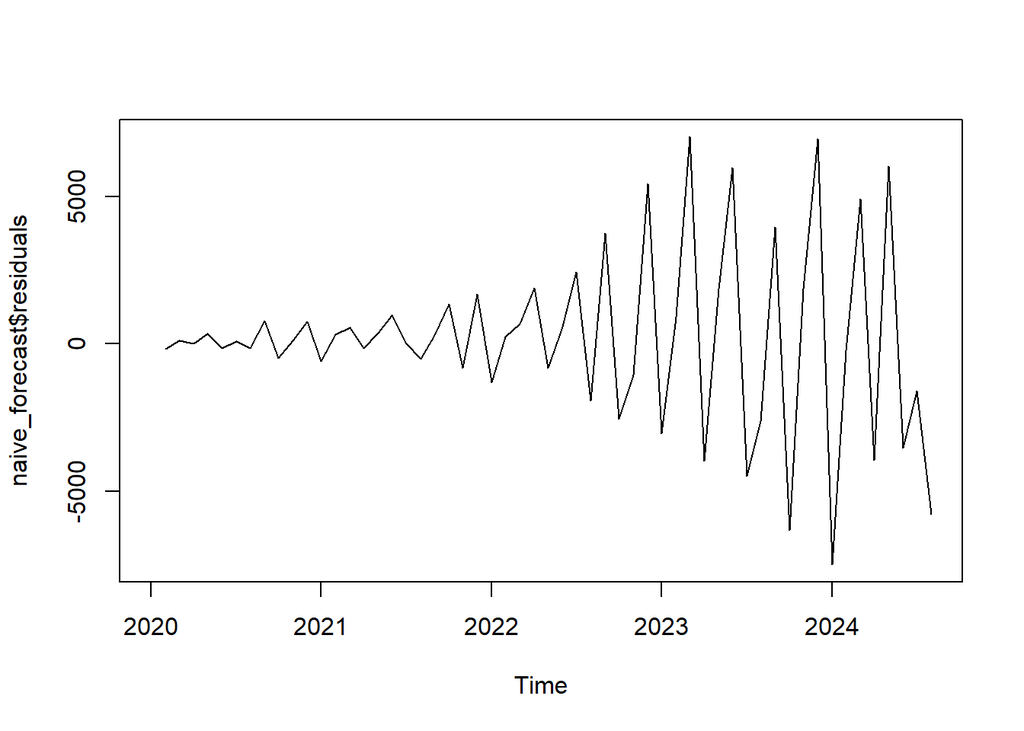

```r
plot(naive_forecast$residuals)
```

###### Residuals Histogram

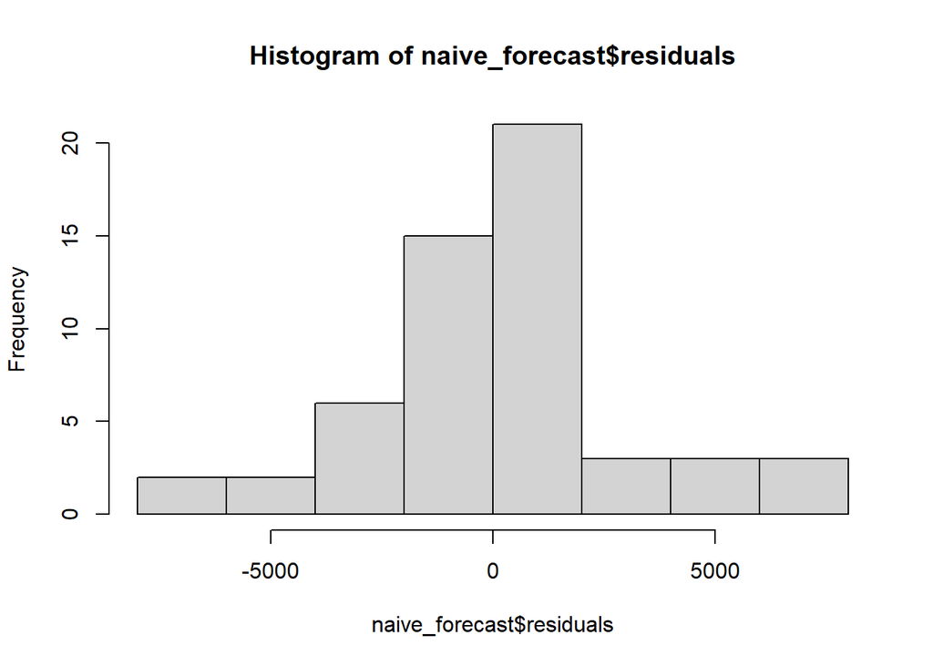

```r
hist(naive_forecast$residuals)
```

- The histogram appears to be normally distributed.
- But the values do not have a mean zero. Although,the histogram appears to be normally on both side.
- This means that the data is biased as the mean is not zero.

###### Fitted vs Residual Values

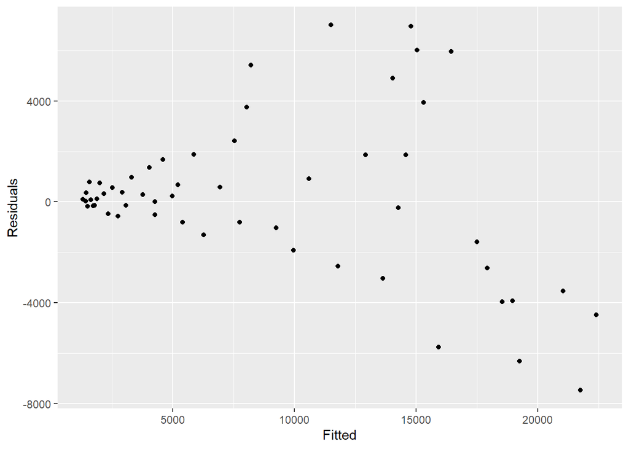

```r
cbind(Fitted = fitted(naive_forecast),
      Residuals = residuals(naive_forecast)) %>%
  as.data.frame() %>%
  ggplot( aes(x= Fitted, y= Residuals)) + geom_point()
```

- The Fitted vs Residuals plot appears to have a trend.
- Also, all the points are starting from mean 0.
- This means there is heteroscedasticity in the errors which means that the variance of the residuals may not be constant.

###### Actual vs Residual values

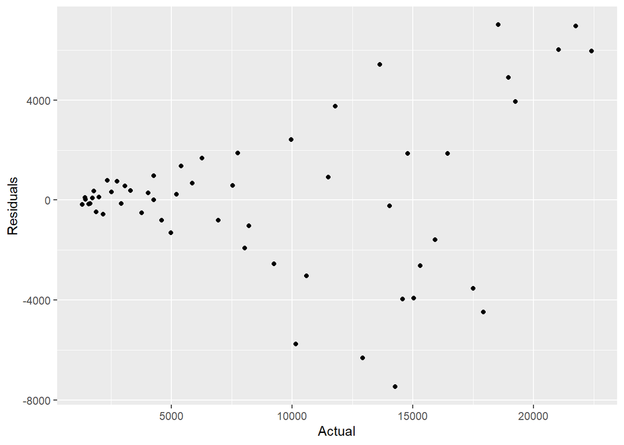

```r
cbind(Actual=sales_ts,
      Residuals=residuals(naive_forecast)) %>%
  as.data.frame() %>%
  ggplot(aes(x=Actual, y=Residuals)) + geom_point()
```

- Similar to the previous plot, The actual vs Residuals plot also appears not to be random.

###### ACF of residuals

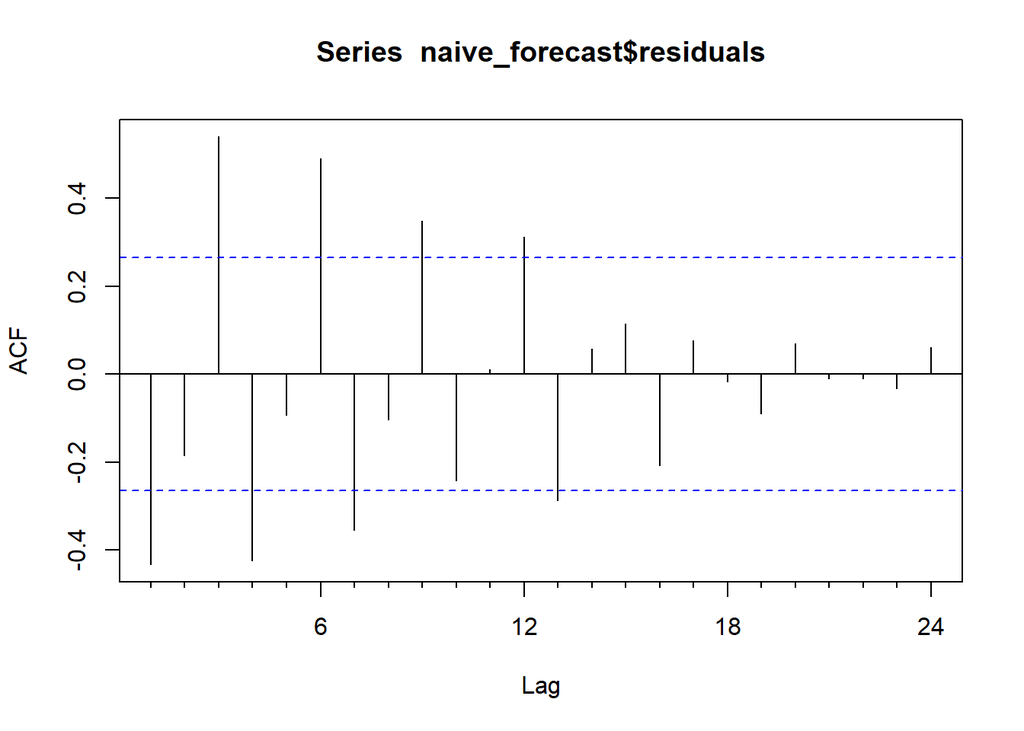

```r
Acf(naive_forecast$residuals)
```

- Some values of the Acf have crossed the confidence level meaning there is a trend in the residuals and we have missed some variable in our forecast.
- The Acf values also show seasonality in the plot and we missed this variable too.
- Meaning that naive forecast is missing some main variables which we have missed our consideration for the forecast.

##### Accuracy

```r
accuracy(naive_forecast)
```

```
##                   ME    RMSE      MAE       MPE     MAPE      MASE      ACF1
## Training set 157.275 3029.52 2104.495 0.6371928 20.12969 0.4670533 -0.433312
```

##### Forecast

```r
forecast(naive_forecast)
```

```
##          Point Forecast      Lo 80    Hi 80      Lo 95    Hi 95
## Sep 2024       10151.93  6269.4469 14034.42  4214.1830 16089.68
## Oct 2024       10151.93  4661.2686 15642.60  1754.6864 18549.18
## Nov 2024       10151.93  3427.2699 16876.60  -132.5517 20436.42
## Dec 2024       10151.93  2386.9609 17916.91 -1723.5671 22027.43
## Jan 2025       10151.93  1470.4302 18833.44 -3125.2797 23429.15
## Feb 2025       10151.93   641.8232 19662.04 -4392.5248 24696.39
## Mar 2025       10151.93  -120.1596 20424.03 -5557.8769 25861.74
## Apr 2025       10151.93  -829.3959 21133.26 -6642.5603 26946.43
## May 2025       10151.93 -1495.5252 21799.39 -7661.3171 27965.18
## Jun 2025       10151.93 -2125.5659 22429.43 -8624.8813 28928.75
```

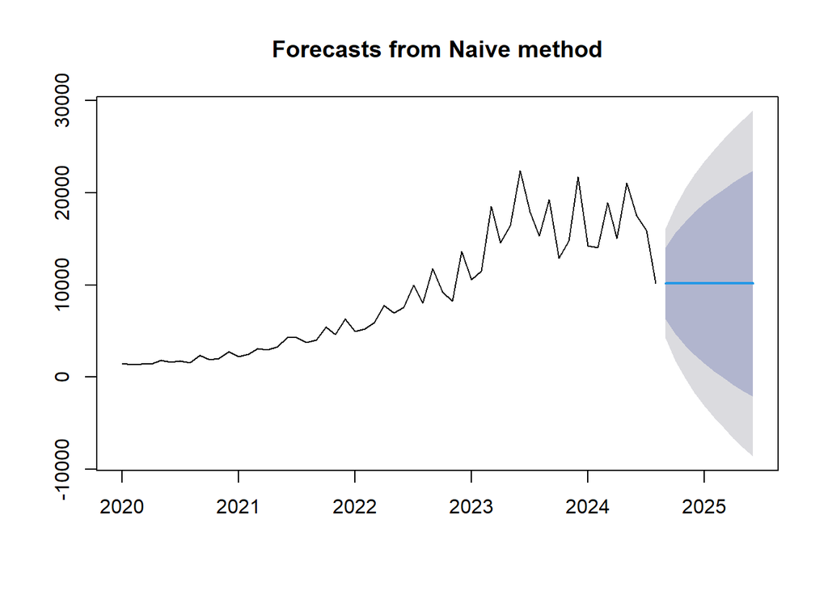

```r
plot(forecast(naive_forecast))
```

##### Naive Method Summary

- The ME, RMSE values are very high indicating that this method may not be the right one to go with.
- We can consider more forecasting techniques and check if the error values are less than this one.
- From Jan 2020 to Jan 2024 there is observed to be an increasing trend in the data. So, naive forecast may not be a right way to forecast.
- Also, the predicted forecast also seems to be stable.

## Simple Moving Averages

##### Plot the graph for time series.

##### Simple Moving average of order 3, 6, and 9

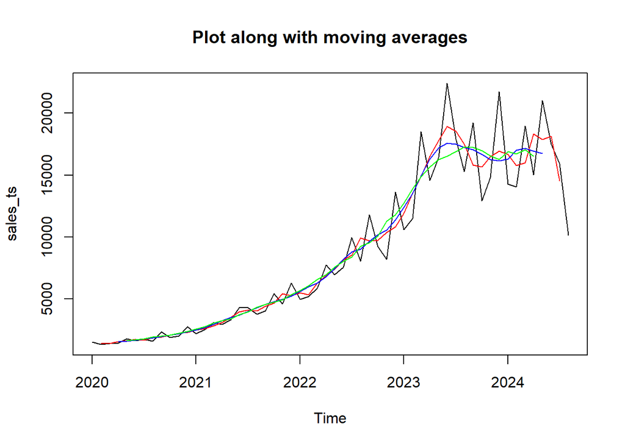

```r
ma3_forecast = ma(sales_ts, order = 3)
ma6_forecast = ma(sales_ts, order = 6)
ma9_forecast = ma(sales_ts, order = 9)
plot(sales_ts, main ="Plot along with moving averages")
lines(ma3_forecast, col='Red')
lines(ma6_forecast, col='Blue')
lines(ma9_forecast, col='Green')
```

[figure not shown]

```r
ma3_forecast = ma(sales_ts, order = 3)
plot(sales_ts, main ="Plot along with moving averages for 12 Months", h=12)
lines(ma3_forecast, col='Red')
```

##### Observations

- From the plots, it is observed that the higher the order we consider, the smoother the moving average curve in the plot.
- It can be seen that the Green line above is the smoothest compared to Blue or Red lines.
- The Red line (order 3) gives the most real data compared to the other two. The higher order averages smoother the plot and do not give the actual values.

## Simple Smoothing

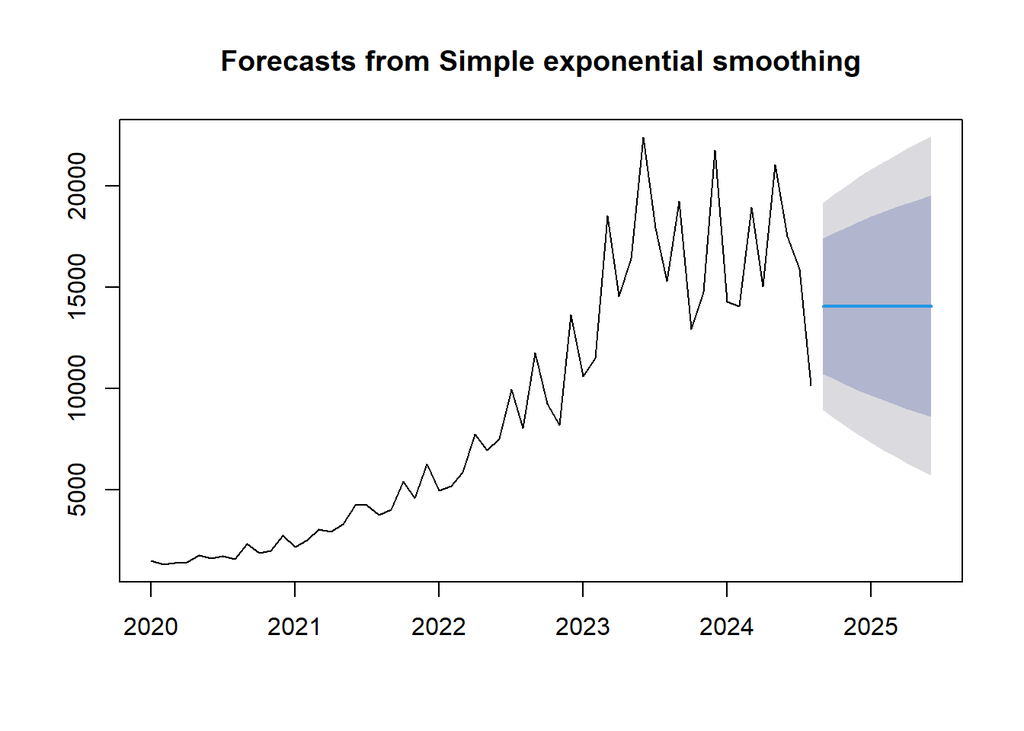

```r
ses_data = ses(sales_ts)
plot(ses_data)
```

```r
attributes(ses_data)
```

```
## $names
##  [1] "model"     "mean"      "level"     "x"         "upper"     "lower"
##  [7] "fitted"    "method"    "series"    "residuals"
##
## $class
## [1] "forecast"
```

```r
summary(ses_data)
```

```
##
## Forecast method: Simple exponential smoothing
##
## Model Information:
## Simple exponential smoothing
##
## Call:
## ses(y = sales_ts)
##
##   Smoothing parameters:
##     alpha = 0.4319
##
##   Initial states:
##     l = 1472.029
##
##   sigma:  2603.101
##
##      AIC     AICc      BIC
## 1110.202 1110.664 1116.279
##
## Error measures:
##                    ME     RMSE      MAE      MPE     MAPE      MASE       ACF1
## Training set 521.0807 2556.194 1608.255 5.757111 15.49006 0.3569223 -0.1451411
##
## Forecasts:
##          Point Forecast     Lo 80    Hi 80    Lo 95    Hi 95
## Sep 2024       14075.16 10739.153 17411.17 8973.177 19177.14
## Oct 2024       14075.16 10441.301 17709.02 8517.652 19632.67
## Nov 2024       14075.16 10166.078 17984.24 8096.735 20053.59
## Dec 2024       14075.16  9908.998 18241.32 7703.564 20446.76
## Jan 2025       14075.16  9666.884 18483.44 7333.284 20817.04
## Feb 2025       14075.16  9437.393 18712.93 6982.307 21168.01
## Mar 2025       14075.16  9218.734 18931.59 6647.897 21502.42
## Apr 2025       14075.16  9009.505 19140.82 6327.909 21822.41
## May 2025       14075.16  8808.582 19341.74 6020.623 22129.70
## Jun 2025       14075.16  8615.047 19535.27 5724.637 22425.68
```

##### Observations

- alpha = 0.4319
- Alpha specifies the coefficient for the level smoothing. Values near 1.0 mean that the latest value has more weight.
- Initial state: l = 1472.029
- Sigma: 2603.101 Sigma defines the variance in the forecast predicted.

##### Residual Analysis

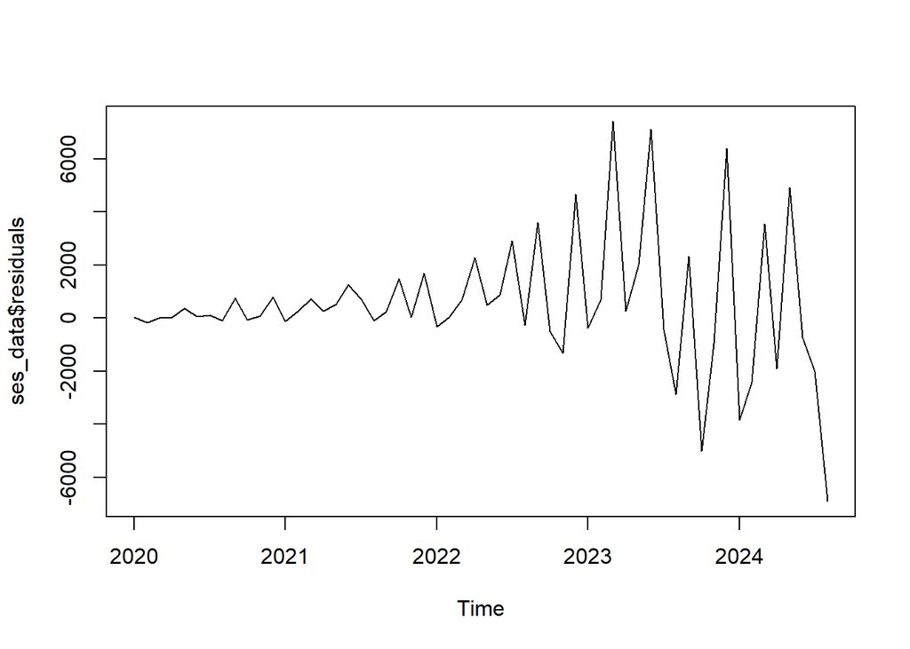

```r
plot(ses_data$residuals)
```

###### Histogram plot of residuals

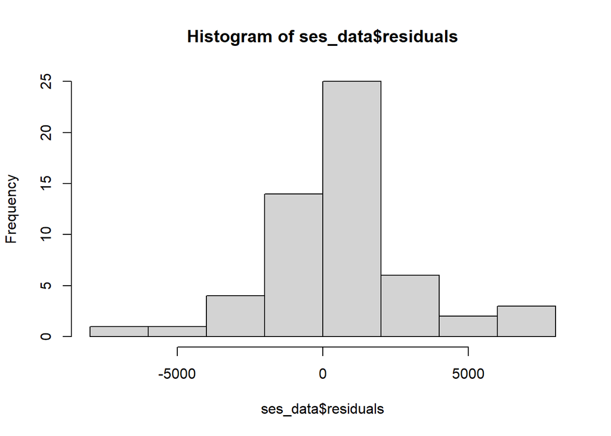

```r
hist(ses_data$residuals)
```

- The histogram appears to be normally distributed.
- But the values do not have a mean zero. The histogram appears to be both side normally.

###### Fitted values vs. residuals

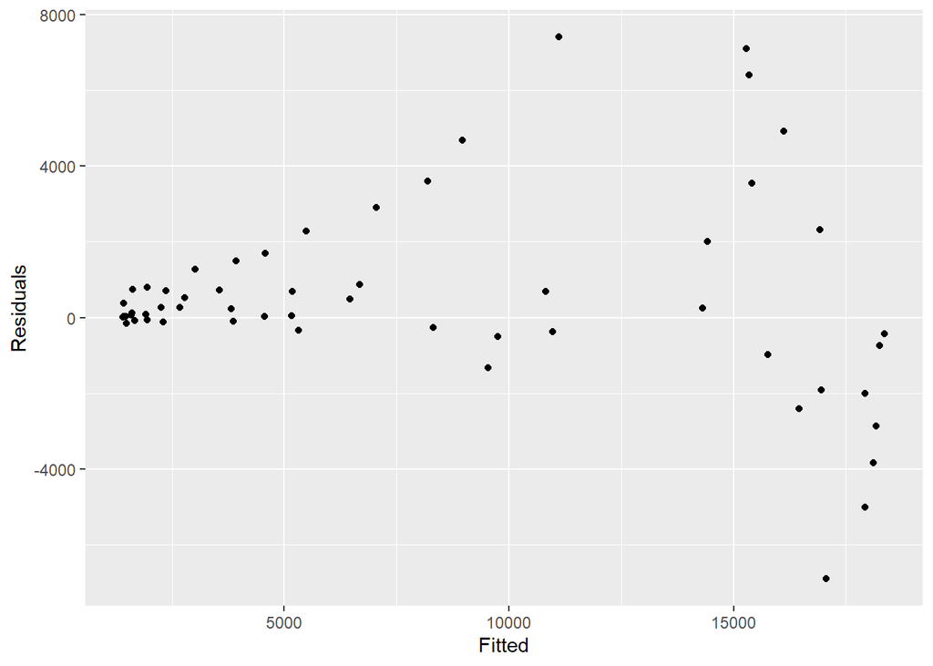

```r
cbind(Fitted=fitted(ses_data),
      Residuals=residuals(ses_data)) %>%
  as.data.frame() %>%
  ggplot(aes(x=Fitted,y=Residuals)) + geom_point()
```

- The Fitted vs Residuals plot appears to have a trend.
- This means there is heteroscedasticity in the errors which means that the variance of the residuals may not be constant.

###### Actual values vs. residuals

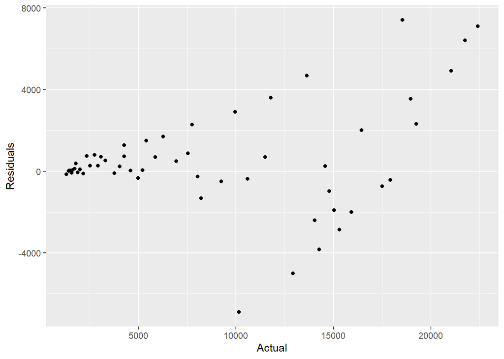

```r
cbind(Actual = sales_ts,
      Residuals=residuals(ses_data)) %>%
  as.data.frame() %>%
  ggplot(aes(x=Actual, y=Residuals)) + geom_point()
```

- Similar to the previous plot, the Actual vs. Residuals plot appears to have some trend in the data.

###### ACF plot of the residuals

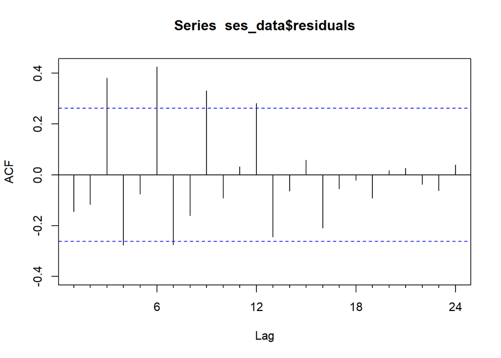

```r
Acf(ses_data$residuals)
```

- Some Values of the Acf have crossed the confidence level meaning there is a trend in the residuals and we have missed some variable in our forecast.
- The Acf values also show seasonality in the plot and we missed this variable too.
- Meaning that simple smoothing is missing some main variables which we have missed our consideration for the forecast.

##### Accuracy

```r
accuracy(ses_data)
```

```
##                    ME     RMSE      MAE      MPE     MAPE      MASE       ACF1
## Training set 521.0807 2556.194 1608.255 5.757111 15.49006 0.3569223 -0.1451411
```

##### Forecast

```r
ses_data
```

```
##          Point Forecast     Lo 80    Hi 80    Lo 95    Hi 95
## Sep 2024       14075.16 10739.153 17411.17 8973.177 19177.14
## Oct 2024       14075.16 10441.301 17709.02 8517.652 19632.67
## Nov 2024       14075.16 10166.078 17984.24 8096.735 20053.59
## Dec 2024       14075.16  9908.998 18241.32 7703.564 20446.76
## Jan 2025       14075.16  9666.884 18483.44 7333.284 20817.04
## Feb 2025       14075.16  9437.393 18712.93 6982.307 21168.01
## Mar 2025       14075.16  9218.734 18931.59 6647.897 21502.42
## Apr 2025       14075.16  9009.505 19140.82 6327.909 21822.41
## May 2025       14075.16  8808.582 19341.74 6020.623 22129.70
## Jun 2025       14075.16  8615.047 19535.27 5724.637 22425.68
```

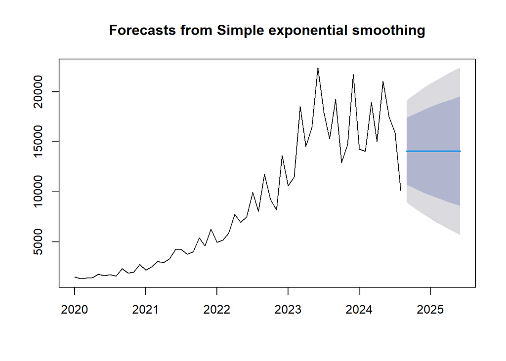

```r
plot(ses_data)
```

##### Simple Smoothing Summary

- The ME, RMSE values are very high indicating that this method may not be the right one to go with.
- We can consider more forecasting techniques and check if the error values are less than this one.
- From Jan 2020 to Jan 2024 there is observed to be an increasing trend in the data. So, this forecast may not be a right way to forecast.
- We can try Holtwinters approach as it suits for trend+seasonal time series

## Holt-Winters

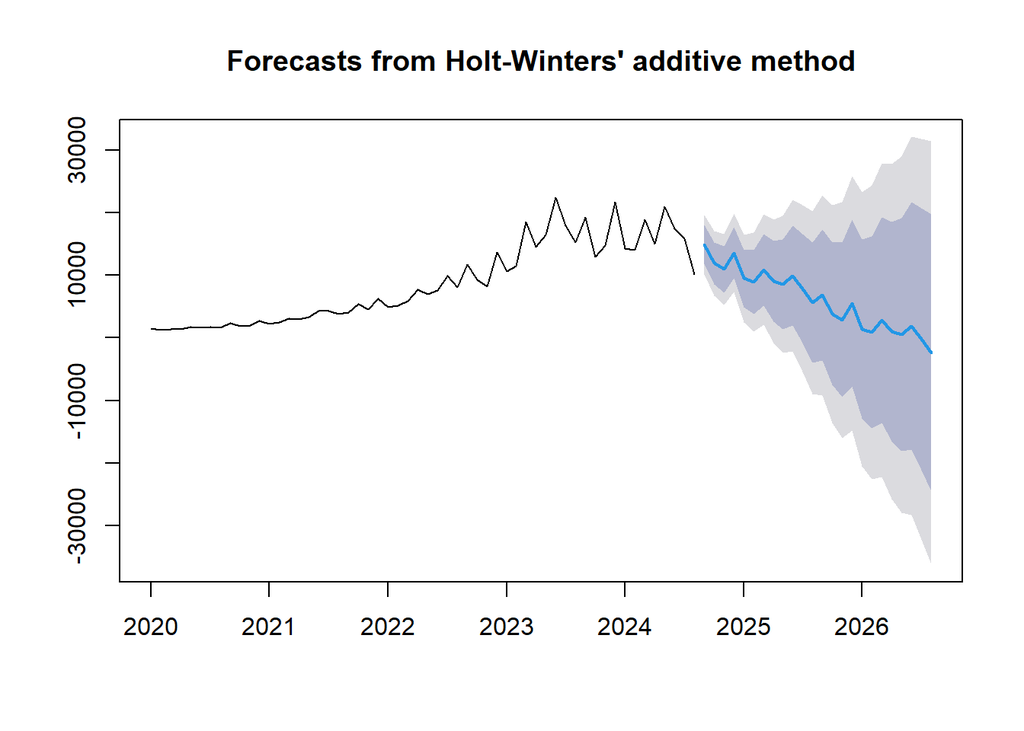

```r
Hw_forecast <- hw(sales_ts, seasonal = "additive")
plot(forecast(Hw_forecast))
```

```r
attributes(Hw_forecast)
```

```
## $names
##  [1] "model"     "mean"      "level"     "x"         "upper"     "lower"
##  [7] "fitted"    "method"    "series"    "residuals"
##
## $class
## [1] "forecast"
```

```r
Hw_add <- forecast(Hw_forecast)
```

- Here, additive Holtwinters method is considered.
- This is because the seasonality isn’t increasing with trend. This is an additive time series.

###### Observations

```r
Hw_add$model
```

```
## Holt-Winters' additive method
##
## Call:
## hw(y = sales_ts, seasonal = "additive")
##
##   Smoothing parameters:
##     alpha = 0.3176
##     beta  = 0.0862
##     gamma = 1e-04
##
##   Initial states:
##     l = 818.4249
##     b = 343.2258
##     s = 1774.076 -1565.1 -1259.728 1059.152 -814.7662 753.5157
##            2154.785 120.2898 -57.6465 1068.374 -1562.394 -1670.559
##
##   sigma:  2428.542
##
##      AIC     AICc      BIC
## 1113.622 1129.728 1148.053
```

- Alpha = 0.3176 Alpha specifies the coefficient for the level smoothing in Holtwinters.
- Beta = 0.0862 Beta specifies the coefficient for the trend smoothing in Holtwinters.
- Gamma = 1e-04 Gamma specifies the coefficient for the seasonal smoothing in Holtwinters.
- Values 1.0 means that the latest value has highest weight.
- Initial states: l = 818.4249 b = 343.2258 s = 1774.076 -1565.1 -1259.728 1059.152 -814.7662 753.5157 2154.785 120.2898 -57.6465 1068.374 -1562.394 -1670.559
- Sigma = 2428.542 Sigma defines the variance of the forecast values.

##### Residual Analysis

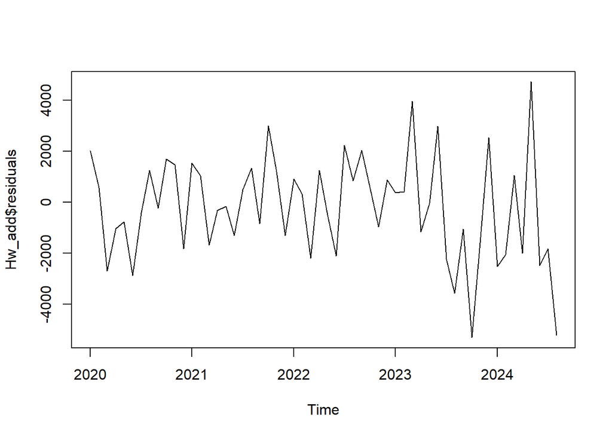

```r
plot(Hw_add$residuals)
```

- The residuals appear to be random and also the mean looks to be near zero. We can check this with histogram.
- We can observe a couple of up and downs throughout. But even they did not show and growing residual pattern.

###### Histogram plot of residuals

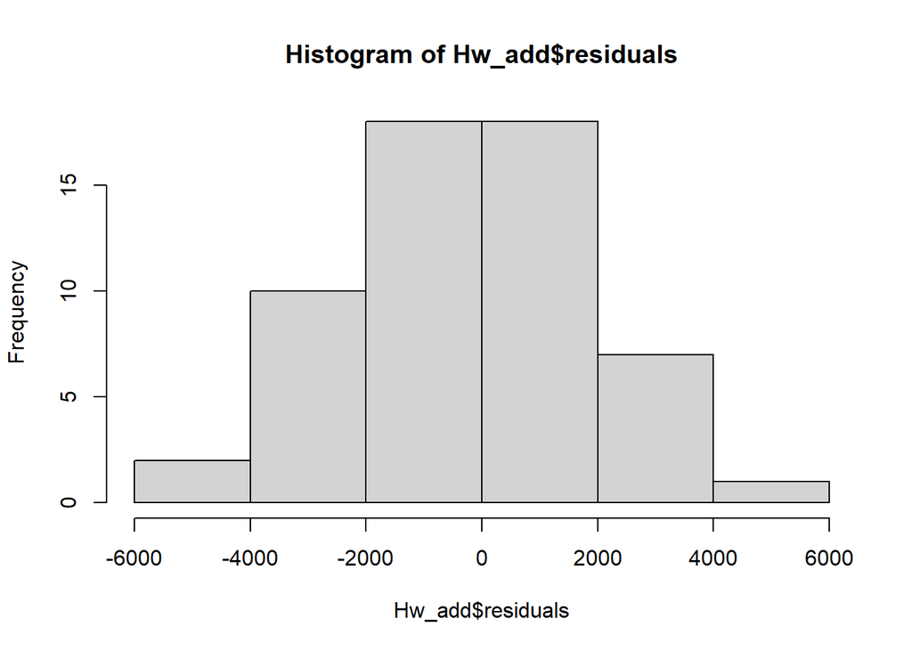

```r
hist(Hw_add$residuals)
```

- The histogram appears to be normally distributed.
- And the mean is near zero. Indicating the data is not biased.
- Overall, comparing the previous forecasts, this forecast appears to be the best till now.

###### Fitted values vs. residuals

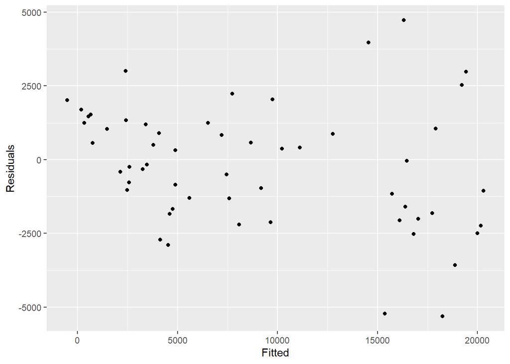

```r
cbind(Fitted = fitted(Hw_add),
      Residuals=residuals(Hw_add)) %>%
  as.data.frame() %>%
  ggplot(aes(x=Fitted, y=Residuals)) + geom_point()
```

- The Fitted vs Residuals plot appears not to have any trend.
- This means there is no heteroscedasticity in the errors which means that the variance of the residuals is constant.

###### Actual values vs. residuals

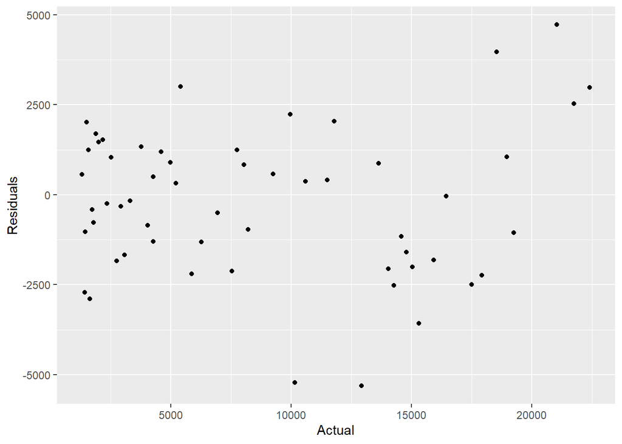

```r
cbind(Actual= sales_ts,
      Residuals=residuals(Hw_add)) %>%
  as.data.frame() %>%
  ggplot(aes(x=Actual, y=Residuals)) + geom_point()
```

- Similar to the previous plot, the Actual vs. Residuals plot appears to be random.

###### ACF plot of the residuals

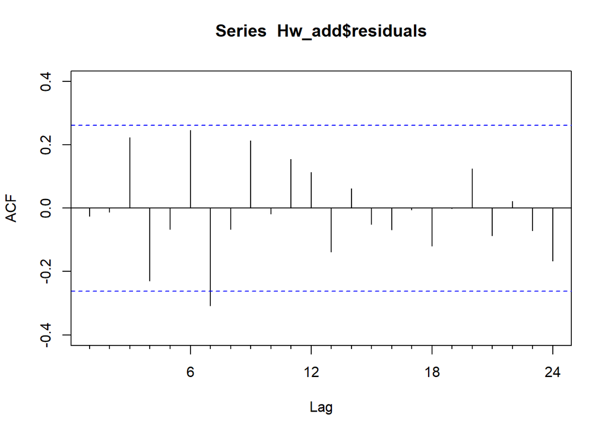

```r
Acf(Hw_add$residuals)
```

##### Accuracy

```r
accuracy(Hw_add)
```

```
##                     ME     RMSE      MAE       MPE     MAPE      MASE
## Training set -210.3775 2052.493 1661.449 -3.401198 33.49673 0.3687275
##                     ACF1
## Training set -0.02495954
```

##### Forecast

```r
forecast(Hw_forecast)
```

```
##          Point Forecast       Lo 80    Hi 80       Lo 95    Hi 95
## Sep 2024     14915.4527  11803.1507 18027.75  10155.5976 19675.31
## Oct 2024     11924.6419   8568.2064 15281.08   6791.4168 17057.87
## Nov 2024     10947.3453   7260.7678 14633.92   5309.2115 16585.48
## Dec 2024     13614.6008   9515.1067 17714.09   7344.9656 19884.24
## Jan 2025      9498.2305   4909.7127 14086.75   2480.6981 16515.76
## Feb 2025      8934.2552   3788.3217 14080.19   1064.2291 16804.28
## Mar 2025     10892.9022   5128.5202 16657.28   2077.0406 19708.76
## Apr 2025      9094.7722   2657.3234 15532.22   -750.4562 18940.00
## May 2025      8601.4220   1441.6443 15761.20  -2348.5131 19551.36
## Jun 2025      9963.0717   2036.0955 17890.05  -2160.1923 22086.34
## Jul 2025      7890.2746   -845.1816 16625.73  -5469.4528 21250.00
## Aug 2025      5649.6904  -3932.5846 15231.97  -9005.1345 20304.52
## Sep 2025      6852.1971  -3612.9262 17317.32  -9152.8279 22857.22
## Oct 2025      3861.3863  -7520.3201 15243.09 -13545.4315 21268.20
## Nov 2025      2884.0897  -9446.3507 15214.53 -15973.6915 21741.87
## Dec 2025      5551.3452  -7758.5086 18861.20 -14804.3196 25907.01
## Jan 2026      1434.9749 -12883.6991 15753.65 -20463.5473 23333.50
## Feb 2026       870.9996 -14484.7896 16226.79 -22613.6533 24355.65
## Mar 2026      2829.6466 -13590.5712 19249.86 -22282.9095 27942.20
## Apr 2026      1031.5167 -16479.5699 18542.60 -25749.3792 27812.41
## May 2026       538.1664 -18089.4447 19165.78 -27950.3064 29026.64
## Jun 2026      1899.8161 -17869.2667 21668.90 -28334.3869 32134.02
## Jul 2026      -172.9810 -21107.8371 20761.88 -32190.0805 31844.12
## Aug 2026     -2413.5652 -24537.9059 19710.78 -36249.8244 31422.69
```

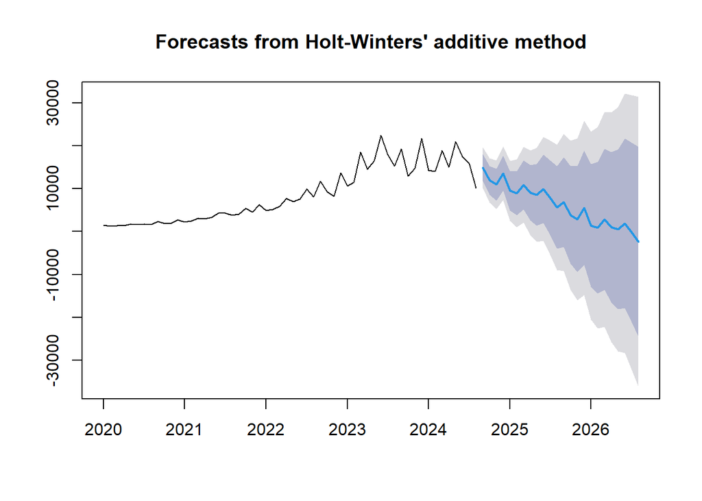

```r
plot(forecast(Hw_forecast))
```

## Accuracy Summary

```r
accuracy(naive_forecast)
```

```
##                   ME    RMSE      MAE       MPE     MAPE      MASE      ACF1
## Training set 157.275 3029.52 2104.495 0.6371928 20.12969 0.4670533 -0.433312
```

```r
accuracy(ses_data)
```

```
##                    ME     RMSE      MAE      MPE     MAPE      MASE       ACF1
## Training set 521.0807 2556.194 1608.255 5.757111 15.49006 0.3569223 -0.1451411
```

```r
accuracy(Hw_add)
```

```
##                     ME     RMSE      MAE       MPE     MAPE      MASE
## Training set -210.3775 2052.493 1661.449 -3.401198 33.49673 0.3687275
##                     ACF1
## Training set -0.02495954
```